# Prevendo resultados de partidas de futebol

Este mini projeto tem como objetivo criar um modelo supervisionado que consiga prever se um time vai ganhar, empatar ou perde o próximo jogo com base nas estáticas de suas últimas partidas.

```r
library(dplyr)
library("lubridate")
library(matrixStats)
library(psych)
# Defenir diretório
setwd("E:/futebol/projeto")

# importando CSVs do campeonato brasileiro de 2019 a até a rodada 6 de 2022
df2019 <- read.csv("2019.csv", encoding = "UTF-8", sep = ";")
df2020 <- read.csv("2020.csv", encoding = "UTF-8", sep = ";")
df2021 <- read.csv("2021.csv", encoding = "UTF-8", sep = ";")
df2022 <- read.csv("2022.csv", encoding = "UTF-8", sep = ";")

# Combinando Csv
df <- rbind(df2019,df2020)
df <- rbind(df, df2021)
df <- rbind(df, df2022)
#View(df)
write.csv(df,"df_combinados.csv",fileEncoding = "UTF-8", row.names = FALSE)
df <- read.csv("df_combinados.csv", encoding = "UTF-8")
# adicionando duas colunas (resultado-casa e resultado-fora)
df <- df %>% mutate(resultado.casa = ifelse(df$gol.casa > df$gol.fora, "venceu",
                                            ifelse(df$gol.casa == df$gol.fora, "empatou", "perdeu")
), .after = 13)
df <- df %>% mutate(resultado.fora = ifelse(df$gol.fora > df$gol.casa, "venceu",
                                            ifelse(df$gol.fora == df$gol.casa, "empatou", "perdeu")
))


# Separando o dataframe pelas colunas casa e fora e depois combinando as duas partes pelas linhas
# para que o data frame tenha os dados por jogo de cada time
nomeC <- c(
  'data',
  'time',
  'gol',
  'chutes',
  'chutesgol'
  ,'possebola',
  'passes',
  'precisaopasses',
  'faltas',
  'cartaoamarelo'
  ,'cartaovermelho',
  'impedimentos',
  'escanteios'
  ,'resultado'
)
# Criando a primeira parte
dfdata <- df[,1] # somente a coluna data
df1 <- df[,2:14] # somente as colunas casa
df1 <- cbind(dfdata, df1) # combinando o df1 com dfdata
colnames(df1) <- nomeC # renomeando as colunas
df1$estadio <- "casa" # adicionando a coluna estadio para definir se o jogos esta jogando em casa ou fora
#View(df1)

# Criando a segunda parte
df2 <- df[,15:27]
df2 <- cbind(dfdata, df2)
colnames(df2) <- nomeC
df2$estadio <- "fora"
#View(df2)

df <- rbind(df1,df2) # Combinando as duas partes pelas linhas
df <- df[, c(1,2,3,4,5,6,7,8,9,10,11,12,13,15,14)] # reordenando


# Formantando e mudando o tipo das colunas 'possebola' e 'precisaopasses'
df$possebola <- as.integer(gsub("%", "", df$possebola))/100
df$precisaopasses <- as.integer(gsub("%", "", df$precisaopasses))/100

# Criando nova coluna para informar o dia da semana (segunda, terça, quarta.. etc.)
dfDiaSemana <- format(as.POSIXct(df$data), format="%Y-%m-%d")
diaSemana <- wday(dfDiaSemana, label = TRUE)
diaSemana <- data.frame(diaSemana)
df <- mutate(df, diaSemana, .after = 1)


# Criando a coluna que define quantos chutes precisa para chutar no gol
df <- df %>%
  mutate(nchutenogol = round(df$chutesgol/df$chutes,2), .after = 4)

# Criando a coluna que define quantos chutes precisa para fazer gol
df <- df %>%
  mutate(nchutefezgol = round(df$gol/df$chutes,2), .after = 1)

#View(df)
write.csv(df,"df_por_jogos.csv",fileEncoding = "UTF-8", row.names = FALSE)
```

Para prever a próximo partida precisamos pegar dados de jogos anteriores. E para simular isso será criado um novo Data Frame com as medianas das colunas númericas das ultimas 3 partidas mantendo os dados das colunas factor atual, porque essas são colunas prevista para a próxima partida.

```r
df <- read.csv("df_por_jogos.csv", encoding = "UTF-8", stringsAsFactors = TRUE)
times <- unique(df$time) # obtendo os times
dfM = data.frame() # novo Data Frame
for (time in times) { # loop por time
  dfTime <- df[ifelse(df$time == time, TRUE,FALSE),] #criando Data frame temporário para o time atual
  dfTime[order(dfTime$data, decreasing=FALSE), ] # ordenando
  colunas_numericas <- sapply(dfTime, is.numeric) # pegando apenas colunas numéricas
  colunas_factor <- sapply(dfTime, is.factor) # pegando apenas colunas factores
  for (linha in 1:nrow(dfTime)) { # loop para percorrer cada linha do Data Frame temporário
    # Calcula a mediana dos ultimos 3 jogos do time
    if(linha >= 4){
      y <- t(
        data.frame(
          colMedians(as.matrix(dfTime[(linha-3):(linha-1),colunas_numericas]), useNames = TRUE))
        )
      rownames(y) <- NULL
      y <- cbind(y, dfTime[linha,colunas_factor ])
      dfM <- rbind(dfM, y) # adiciona a linha nova com as medianas no Data Frame novo
    }
  }
}
dfM <- data.frame(lapply(dfM, function(x) if(is.numeric(x)) round(x, 2) else x)) # arredondando para duas casa decimais

write.csv(dfM,"df_por_jogos_medianas.csv",fileEncoding = "UTF-8", row.names = FALSE)

#Criando a versão normalizada do novo Data Frame
normalizar <- function(x) {
  return ((x - min(x)) / (max(x) - min(x)))
}
colunas_factor <- sapply(dfM, is.factor)
colunas_numericas <- sapply(dfM, is.numeric)
dfBCKP <- dfM
dfM <- lapply(dfM[,colunas_numericas], normalizar)
dfM$data <- dfBCKP$data
dfM$diaSemana <- dfBCKP$diaSemana
dfM$time <- dfBCKP$time
dfM$estadio <- dfBCKP$estadio
dfM$resultado <- dfBCKP$resultado
dfM <- as.data.frame(dfM, stringsAsFactors = FALSE)

write.csv(dfM,"df_por_jogos_medianaas_normalizado.csv",fileEncoding = "UTF-8", row.names = FALSE)
```

Vamos analisar as colunas do Data frame.

```r
########### Analisando o Data Frame ###################################################
df <- read.csv("df_por_jogos_medianas.csv", encoding = "UTF-8", stringsAsFactors = TRUE)
dfnomalizado <- read.csv("df_por_jogos_medianaas_normalizado.csv", encoding = "UTF-8", stringsAsFactors = TRUE)
#View(df)

# Verificando valores Na
colSums(is.na(df))
```

```
##   nchutefezgol            gol    nchutenogol         chutes      chutesgol
##              0              0              0              0              0
##      possebola         passes precisaopasses         faltas  cartaoamarelo
##              0              0              0              0              0
## cartaovermelho   impedimentos     escanteios           data      diaSemana
##              0              0              0              0              0
##           time        estadio      resultado
##              0              0              0
```

```r
colSums(is.na(dfnomalizado))
```

```
##   nchutefezgol            gol    nchutenogol         chutes      chutesgol
##              0              0              0              0              0
##      possebola         passes precisaopasses         faltas  cartaoamarelo
##              0              0              0              0              0
## cartaovermelho   impedimentos     escanteios           data      diaSemana
##              0              0              0              0              0
##           time        estadio      resultado
##              0              0              0
```

```r
# Tipo de dados
str(df)
```

```
## 'data.frame':    2261 obs. of  18 variables:
##  $ nchutefezgol  : num  0.04 0.08 0.08 0.13 0.13 0.13 0.14 0.14 0.18 0 ...
##  $ gol           : int  1 1 1 2 2 3 3 3 2 0 ...
##  $ nchutenogol   : num  0.42 0.33 0.33 0.39 0.39 0.39 0.45 0.45 0.36 0.33 ...
##  $ chutes        : int  24 13 12 12 14 22 14 18 11 18 ...
##  $ chutesgol     : int  8 7 6 6 6 9 8 8 4 4 ...
##  $ possebola     : num  0.57 0.57 0.66 0.69 0.69 0.68 0.64 0.64 0.65 0.65 ...
##  $ passes        : int  570 570 622 622 622 628 628 609 609 609 ...
##  $ precisaopasses: num  0.86 0.88 0.88 0.88 0.88 0.88 0.89 0.88 0.89 0.9 ...
##  $ faltas        : int  10 8 10 17 17 13 13 12 12 12 ...
##  $ cartaoamarelo : int  2 1 1 2 2 0 0 1 1 3 ...
##  $ cartaovermelho: int  0 0 0 0 0 0 0 0 0 0 ...
##  $ impedimentos  : int  0 0 2 3 2 1 0 1 1 1 ...
##  $ escanteios    : int  12 10 10 10 4 11 6 10 6 10 ...
##  $ data          : Factor w/ 340 levels "01/02/21","01/05/19",..: 85 146 47 190 170 289 50 101 178 301 ...
##  $ diaSemana     : Factor w/ 7 levels "dom","qua","qui",..: 3 6 6 4 4 4 2 5 2 7 ...
##  $ time          : Factor w/ 27 levels "América-MG","Athletico-PR",..: 20 20 20 20 20 20 20 20 20 20 ...
##  $ estadio       : Factor w/ 2 levels "casa","fora": 1 1 1 1 1 1 1 1 1 1 ...
##  $ resultado     : Factor w/ 3 levels "empatou","perdeu",..: 3 3 1 1 3 3 1 3 2 3 ...
```

```r
str(dfnomalizado)
```

```
## 'data.frame':    2261 obs. of  18 variables:
##  $ nchutefezgol  : num  0.1 0.2 0.2 0.325 0.325 0.325 0.35 0.35 0.45 0 ...
##  $ gol           : num  0.25 0.25 0.25 0.5 0.5 0.75 0.75 0.75 0.5 0 ...
##  $ nchutenogol   : num  0.538 0.423 0.423 0.5 0.5 ...
##  $ chutes        : num  0.875 0.417 0.375 0.375 0.458 ...
##  $ chutesgol     : num  0.727 0.636 0.545 0.545 0.545 ...
##  $ possebola     : num  0.617 0.617 0.809 0.872 0.872 ...
##  $ passes        : num  0.583 0.583 0.67 0.67 0.67 ...
##  $ precisaopasses: num  0.828 0.897 0.897 0.897 0.897 ...
##  $ faltas        : num  0.238 0.143 0.238 0.571 0.571 ...
##  $ cartaoamarelo : num  0.333 0.167 0.167 0.333 0.333 ...
##  $ cartaovermelho: num  0 0 0 0 0 0 0 0 0 0 ...
##  $ impedimentos  : num  0 0 0.4 0.6 0.4 0.2 0 0.2 0.2 0.2 ...
##  $ escanteios    : num  0.8 0.667 0.667 0.667 0.267 ...
##  $ data          : Factor w/ 340 levels "01/02/21","01/05/19",..: 85 146 47 190 170 289 50 101 178 301 ...
##  $ diaSemana     : Factor w/ 7 levels "dom","qua","qui",..: 3 6 6 4 4 4 2 5 2 7 ...
##  $ time          : Factor w/ 27 levels "América-MG","Athletico-PR",..: 20 20 20 20 20 20 20 20 20 20 ...
##  $ estadio       : Factor w/ 2 levels "casa","fora": 1 1 1 1 1 1 1 1 1 1 ...
##  $ resultado     : Factor w/ 3 levels "empatou","perdeu",..: 3 3 1 1 3 3 1 3 2 3 ...
```

[figure not shown]

```r
# Analisando a Correlação entre as variáveis numéricas
corPlot(df[,colunas_numericas], cex = 1.2)
```

```r
# Mostrando a distribuição de cada Coluna
for (colnomes in colnames(df[,colunas_numericas])) {
  print("#################")
  print(colnomes)
  print(summary(as.factor(df[,colnomes])))
  print("-----------------")
  print(summary(df[,colnomes]))
}
```

```
## [1] "#################"
## [1] "nchutefezgol"
##    0 0.03 0.04 0.05 0.06 0.07 0.08 0.09  0.1 0.11 0.12 0.13 0.14 0.15 0.16 0.17
##  543    6   22   83  144  164  225  132  131  163  132   53   93   42    9   94
## 0.18 0.19  0.2 0.21 0.22 0.23 0.24 0.25 0.27 0.29  0.3 0.31 0.33 0.38  0.4
##   81    4   47    8   24    3    1   34    3    3    5    2    7    2    1
## [1] "-----------------"
##    Min. 1st Qu.  Median    Mean 3rd Qu.    Max.
## 0.00000 0.04000 0.08000 0.08585 0.12000 0.40000
## [1] "#################"
## [1] "gol"
##    0    1    2    3    4
##  543 1133  470  104   11
## [1] "-----------------"
##    Min. 1st Qu.  Median    Mean 3rd Qu.    Max.
```

[output cut: 112 more lines]

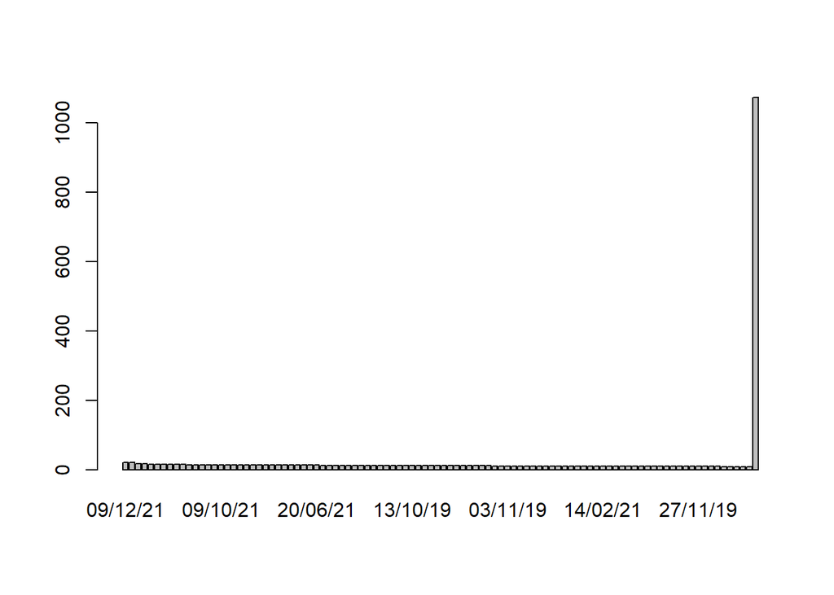

```
## [1] "#################"
## [1] "data"
## 09/12/21 25/02/21 08/12/19 27/06/21 02/09/20 06/10/21 07/07/21 07/10/20
##       20       20       18       18       16       16       16       16
## 13/09/20 14/11/20 01/12/19 06/09/20 08/05/22 08/11/20 09/10/19 09/10/21
##       16       16       14       14       14       14       14       14
## 10/11/21 13/06/21 16/10/19 17/10/21 17/11/21 24/01/21 26/09/21 30/05/21
##       14       14       14       14       14       14       14       14
## 30/06/21 31/01/21 02/06/19 04/07/21 16/08/20 19/08/20 20/06/21 01/08/21
##       14       14       13       13       13       13       13       12
## 04/08/19 04/10/20 04/12/19 06/01/21 06/12/21 07/09/19 09/09/20 10/04/22
##       12       12       12       12       12       12       12       12
## 10/07/21 10/11/19 11/10/20 12/08/20 12/12/20 13/10/19 13/10/21 14/10/20
##       12       12       12       12       12       12       12       12
## 15/08/21 17/04/22 20/01/21 20/10/19 21/02/21 24/11/19 25/07/21 25/08/19
##       12       12       12       12       12       12       12       12
## 27/12/20 30/10/19 24/06/21 03/02/21 03/11/19 05/10/19 05/12/20 06/06/21
##       12       12       11       10       10       10       10       10
## 06/10/19 06/11/19 07/11/21 08/06/19 08/08/21 10/01/21 10/02/21 11/08/19
##       10       10       10       10       10       10       10       10
## 12/06/19 12/09/21 13/11/21 14/02/21 14/05/22 14/07/19 15/09/19 17/01/21
##       10       10       10       10       10       10       10       10
## 17/11/19 18/07/21 18/08/19 18/09/21 20/11/21 22/08/21 22/11/20 23/04/22
##       10       10       10       10       10       10       10       10
## 23/08/20 27/09/20 27/11/19 28/07/19 29/09/19 31/08/19 17/06/21 01/05/22
##       10       10       10       10       10       10        9        8
## 01/09/19 01/11/20 02/10/21  (Other)
##        8        8        8     1074
```

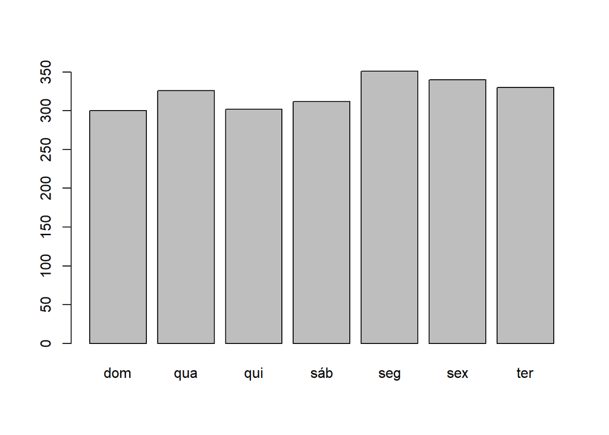

```
## [1] "#################"
## [1] "diaSemana"
## dom qua qui sáb seg sex ter
## 300 326 302 312 351 340 330
```

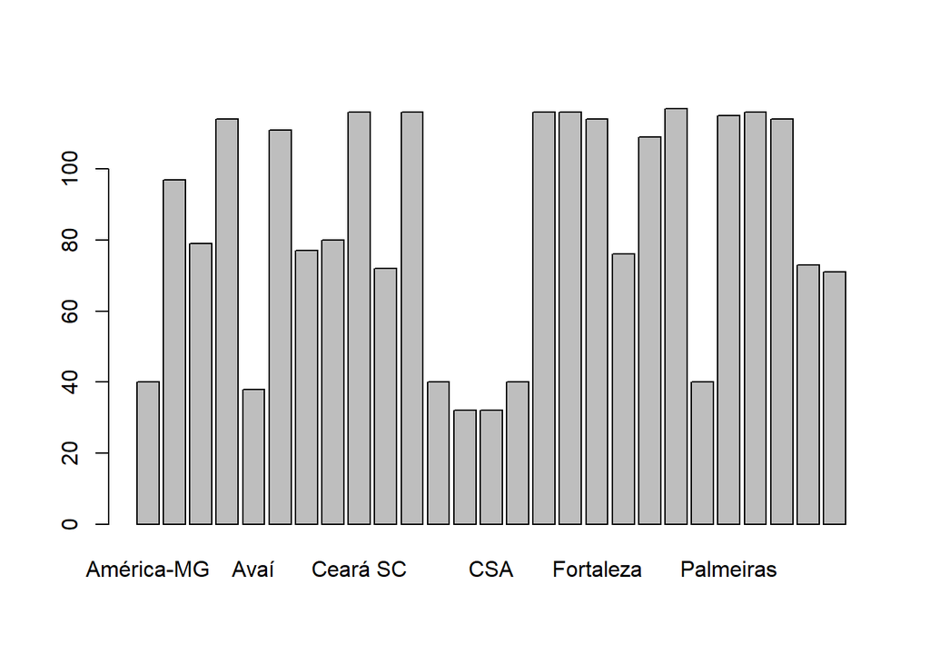

```
## [1] "#################"
## [1] "time"
##    América-MG  Athletico-PR   Atlético-GO   Atlético-MG          Avaí
##            40            97            79           114            38
##         Bahia      Botafogo    Bragantino      Ceará SC   Chapecoense
##           111            77            80           116            72
##   Corinthians      Coritiba      Cruzeiro           CSA        Cuiabá
##           116            40            32            32            40
##      Flamengo    Fluminense     Fortaleza         Goiás        Grêmio
##           116           116           114            76           109
## Internacional     Juventude     Palmeiras        Santos     São Paulo
##           117            40           115           116           114
##  Sport Recife Vasco da Gama
##            73            71
```

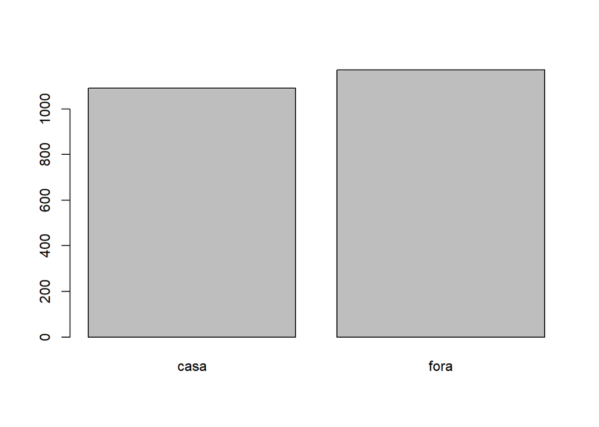

```
## [1] "#################"
## [1] "estadio"
## casa fora
## 1090 1171
```

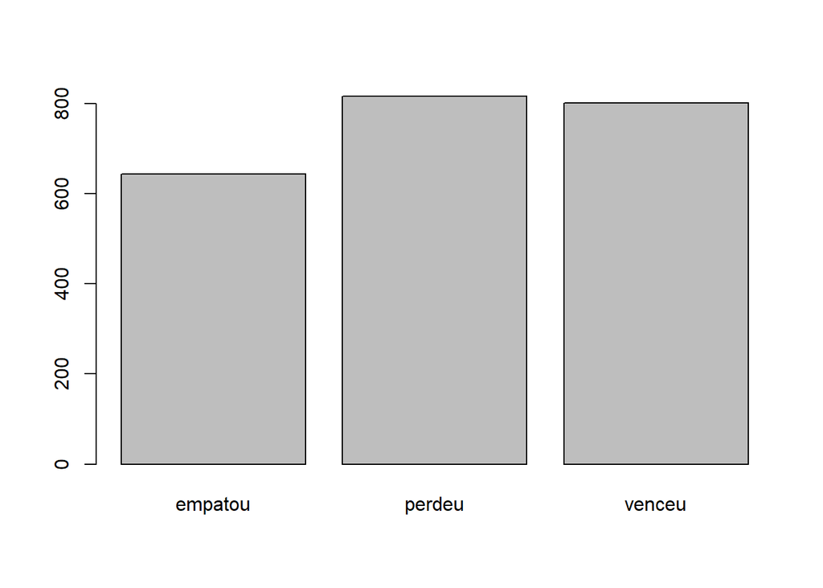

```
## [1] "#################"
## [1] "resultado"
## empatou  perdeu  venceu
##     644     816     801
```

```r
for (colnomes in colnames(df[,colunas_factor])) {
  barplot(summary(df[,colnomes]))
  print("#################")
  print(colnomes)
  print(summary(df[,colnomes]))
}
```

Agora o Data Frame será dividido em treino e teste e logo em seguida será feito o treinamento e teste com 4 algoritmos diferentes.

```r
library(caret)
library(randomForest)
library(rpart)
library(e1071)
library(ROSE)
# dividindo Data Frame em treino e teste
# poderá escolher entre o normalizado ou não
df <- df[, -14]
#df <- dfnomalizado[,-14]

linhas <- sample(1:nrow(df), 0.70 * nrow(df))
dados_treino <- df[linhas,]
dados_teste <- df[-linhas,]
summary(dados_treino$resultado)
```

```
## empatou  perdeu  venceu
##     443     578     561
```

```r
summary(dados_teste$resultado)
```

```
## empatou  perdeu  venceu
##     201     238     240
```

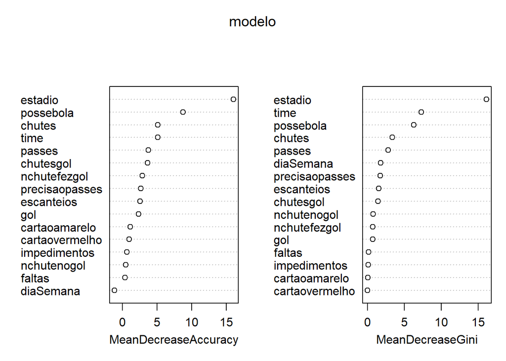

```r
#View(dados_treino)


# Random forest
modelo <- randomForest( resultado ~ .
                        #-gol
                        #-possebola
                        #-faltas
                        #-impedimentos
                        #-diaSemana
                        #chutes
                        #passes
                        #-cartaoamarelo
                        #escanteios
                        #-time
                        #chutesgol
                        #-precisaopasses
                        #-cartaovermelho
                        #-estadio
                        ,
                        data = dados_treino,
                        ntree = 200, nodesize = 400, importance = T)
varImpPlot(modelo) # gráfico para análise de importância de cada variável
```

```r
pred <- predict(modelo, dados_teste[,-17], type='class')
caret::confusionMatrix(dados_teste$resultado, pred)
```

```
## Confusion Matrix and Statistics
##
##           Reference
## Prediction empatou perdeu venceu
##    empatou       0     94    107
##    perdeu        0    162     76
##    venceu        0     72    168
##
## Overall Statistics
##
##                Accuracy : 0.486
##                  95% CI : (0.4478, 0.5243)
##     No Information Rate : 0.5169
##     P-Value [Acc > NIR] : 0.9506
##
##                   Kappa : 0.2068
##
##  Mcnemar's Test P-Value : <2e-16
##
## Statistics by Class:
##
##                      Class: empatou Class: perdeu Class: venceu
## Sensitivity                      NA        0.4939        0.4786
## Specificity                   0.704        0.7835        0.7805
## Pos Pred Value                   NA        0.6807        0.7000
## Neg Pred Value                   NA        0.6236        0.5831
## Prevalence                    0.000        0.4831        0.5169
## Detection Rate                0.000        0.2386        0.2474
## Detection Prevalence          0.296        0.3505        0.3535
## Balanced Accuracy                NA        0.6387        0.6296
```

```r
# rpart
modelo_rf_v3 = rpart(resultado ~ .
                     #-gol
                     #-possebola
                     #-faltas
                     #-impedimentos
                     #-diaSemana
                     #chutes
                     #passes
                     #-cartaoamarelo
                     #escanteios
                     #-time
                     #chutesgol
                     #-precisaopasses
                     #-cartaovermelho
                     #-estadio
                     ,
                     data = dados_treino,
                     control = rpart.control(cp = .0010))
pred <- predict(modelo_rf_v3, dados_teste[,-17], type='class')
caret::confusionMatrix(dados_teste$resultado, pred)
```

```
## Confusion Matrix and Statistics
##
##           Reference
## Prediction empatou perdeu venceu
##    empatou      41     79     81
##    perdeu       48    116     74
##    venceu       48     73    119
##
## Overall Statistics
##
##                Accuracy : 0.4065
##                  95% CI : (0.3693, 0.4445)
##     No Information Rate : 0.4035
##     P-Value [Acc > NIR] : 0.452320
##
##                   Kappa : 0.0998
##
##  Mcnemar's Test P-Value : 0.001126
##
## Statistics by Class:
##
##                      Class: empatou Class: perdeu Class: venceu
## Sensitivity                 0.29927        0.4328        0.4343
## Specificity                 0.70480        0.7032        0.7012
## Pos Pred Value              0.20398        0.4874        0.4958
## Neg Pred Value              0.79916        0.6553        0.6469
## Prevalence                  0.20177        0.3947        0.4035
## Detection Rate              0.06038        0.1708        0.1753
## Detection Prevalence        0.29602        0.3505        0.3535
## Balanced Accuracy           0.50203        0.5680        0.5678
```

```r
#naiveBayes
modeloV2 <- naiveBayes(resultado ~ .
                       #-gol
                       #-possebola
                       #-faltas
                       #-impedimentos
                       #diaSemana
                       #chutes
                       #passes
                       #-cartaoamarelo
                       #escanteios
                       #-time
                       #-chutesgol
                       #-precisaopasses
                       #-cartaovermelho
                       #-estadio
                       ,
                       data = dados_treino, laplace = 6)

pred <- predict(modeloV2, dados_teste[,-17], type='class')
caret::confusionMatrix(dados_teste$resultado, pred)
```

```
## Confusion Matrix and Statistics
##
##           Reference
## Prediction empatou perdeu venceu
##    empatou      23     93     85
##    perdeu       23    155     60
##    venceu       28     76    136
##
## Overall Statistics
##
##                Accuracy : 0.4624
##                  95% CI : (0.4244, 0.5008)
##     No Information Rate : 0.4772
##     P-Value [Acc > NIR] : 0.79
##
##                   Kappa : 0.1783
##
##  Mcnemar's Test P-Value : 1.033e-15
##
## Statistics by Class:
##
##                      Class: empatou Class: perdeu Class: venceu
## Sensitivity                 0.31081        0.4784        0.4840
## Specificity                 0.70579        0.7662        0.7387
## Pos Pred Value              0.11443        0.6513        0.5667
## Neg Pred Value              0.89331        0.6168        0.6697
## Prevalence                  0.10898        0.4772        0.4138
## Detection Rate              0.03387        0.2283        0.2003
## Detection Prevalence        0.29602        0.3505        0.3535
## Balanced Accuracy           0.50830        0.6223        0.6113
```

```r
# modelo e1071
modelo_svm_v1 <- svm(resultado ~ .
                     #-gol
                     #-possebola
                     #-faltas
                     #-impedimentos
                     #diaSemana
                     #chutes
                     #passes
                     #-cartaoamarelo
                     #escanteios
                     #-time
                     #-chutesgol
                     #-precisaopasses
                     #-cartaovermelho
                     #-estadio
                     ,
                     data = dados_treino,
                     type = 'C-classification',
                     kernel = 'polynomial')
pred <- predict(modelo_svm_v1, dados_teste[,-17])
caret::confusionMatrix(dados_teste$resultado, pred)
```

```
## Confusion Matrix and Statistics
##
##           Reference
## Prediction empatou perdeu venceu
##    empatou       1    174     26
##    perdeu        0    226     12
##    venceu        0    188     52
##
## Overall Statistics
##
##                Accuracy : 0.4109
##                  95% CI : (0.3736, 0.449)
##     No Information Rate : 0.866
##     P-Value [Acc > NIR] : 1
##
##                   Kappa : 0.0925
##
##  Mcnemar's Test P-Value : <2e-16
##
## Statistics by Class:
##
##                      Class: empatou Class: perdeu Class: venceu
## Sensitivity                1.000000        0.3844       0.57778
## Specificity                0.705015        0.8681       0.68081
## Pos Pred Value             0.004975        0.9496       0.21667
## Neg Pred Value             1.000000        0.1791       0.91344
## Prevalence                 0.001473        0.8660       0.13255
## Detection Rate             0.001473        0.3328       0.07658
## Detection Prevalence       0.296024        0.3505       0.35346
## Balanced Accuracy          0.852507        0.6262       0.62930
```

Obs: foram feitas inúmeras otimizações, mas não houve melhorias nos modelos.